# R Notebook

https://www.analyticsvidhya.com/blog/2019/01/fundamentals-deep-learning-recurrent-neural-networks-scratch-python/

```r
library(dplyr)
library(tidyverse)
library(profvis)
```

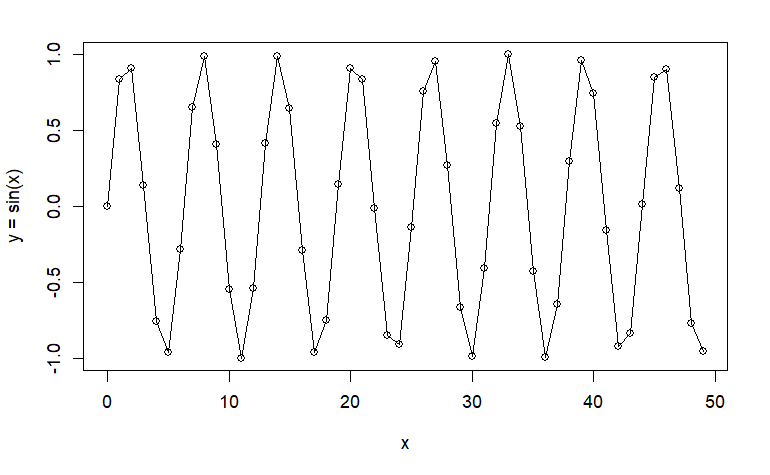

```r
sine <- as.matrix(sin(0:199))
plot(0:49, sine[1:50],xlab="x",ylab="y = sin(x)")
lines(0:49, sine[1:50])
```

We prepare our dataset, where X refers to windows of 50 values of sin(x). For example, the first row would include the values of sine from 1 to 50, the second row would include the values of sine from 2 to 51, etc.

y will refer to the next value that comes in this sequence. So the first row would be the value of sin(51), the second row would be the value of sin(52), etc.

```r
X = NULL
Y = NULL

sequence_length = 50
num_records = length(sine) - sequence_length

for (i in 1:(num_records-50)){
  X = rbind(X, sine[i:(i+sequence_length-1)])
  Y = rbind(Y, sine[i+sequence_length])
}
```

The remaining records will be used as our validation set.

```r
X_val = NULL
Y_val = NULL

for (i in (num_records-49):(num_records)){
  X_val = rbind(X_val, sine[i:(i+sequence_length-1)])
  Y_val = rbind(Y_val, sine[i+sequence_length])
}
```

We set up the necessary hyperparameters for our RNN model.

```r
learning_rate = 0.0001
epochs = 10
hidden_dim = 100
output_dim = 1

bptt_truncate = 5
min_clip_value = -10
max_clip_value = 10
```

```r
U <- read.csv("U.csv", header=F)
W <- read.csv("W.csv", header=F)
V <- read.csv("V.csv", header=F)

U <- as.matrix(U)
V <- as.matrix(V)
W <- as.matrix(W)
```

We will also need our dearest sigmoid function.

```r
sigmoid <- function(x){
  1 / (1 + exp(-x))
}
```

We first do a forward pass through the RNN and calculate the squared error of all the predictions, yielding us the loss value for the both the training and validation set.

```r
for (epoch in 1:epochs){
  loss = 0

  for (i in 1:dim(Y)[1]){
    x <- X[i,]
    y <- Y[i]
    prev_s <- rep(0, hidden_dim) # Initializing the previous activation as a vector of 0s.
    for (t in 1:sequence_length){
      new_input <- rep(0, length(x))
      new_input[t] <- x[t]
      mulu <- U %*% new_input
      mulw <- W %*% prev_s
      add <- mulw + mulu
      s = sigmoid(add)
      mulv <- V %*% s
      prev_s <- s
    }

    loss_per_record <- ((y - mulv)^2)/2
    loss = loss + loss_per_record
  }
  loss = loss/length(y)

  val_loss = 0
  for (i in 1:dim(Y_val)[1]){
    x <- X_val[i,]
    y <- Y_val[i]
    prev_s <- rep(0, hidden_dim)
    for (t in 1:sequence_length){
      new_input <- rep(0, length(x))
      new_input[t] <- x[t]
      mulu <- U %*% new_input
      mulw <- W %*% prev_s
      add <- mulw + mulu
      s = sigmoid(add)
      mulv <- V %*% s
      prev_s <- s
    }

    loss_per_record <- ((y - mulv)^2)/2
    val_loss = val_loss + loss_per_record
  }
  val_loss <- val_loss/length(y)
  print(paste0("Epoch: ", epoch, ", Loss: ", loss, ", Val Loss: ", val_loss))

  for (i in 1:dim(Y)[1]){
    x <- X[i,]
    y <- Y[i]

    layers <- array(rep(NaN, sequence_length * hidden_dim * 2), c(sequence_length, 2, hidden_dim)) # Our layers matrix for the given sequence_length = 50, hidden_dim = 100, is 50 x 2 x 100. Hence, we initialize an array with NaN on those dimensions here.
    prev_s <- rep(0, hidden_dim)
    dU <- 0 * U
    dV <- 0 * V
    dW <- 0 * W

    dU_t <- 0 * U
    dV_t <- 0 * V
    dW_t <- 0 * W

    dU_i <- 0 * U
    dW_i <- 0 * W
    for (t in 1:sequence_length){
      new_input <- rep(0, length(x))
      new_input[t] <- x[t]
      mulu <- U %*% new_input
      mulw <- W %*% prev_s
      add <- mulw + mulu
      s = sigmoid(add)
      mulv <- V %*% s
      layers[t,1,] <- s
      layers[t,2,] <- prev_s
      prev_s <- s
    }

    dmulv <- mulv - y

    for (t in 1:sequence_length){
      dV_t <- dmulv %*% t(layers[t,1,])
      dsv <- t(V) %*% dmulv

      ds = dsv
      dadd = add * (1 - add) * ds

      dmulw = dadd * rep(1, length(mulw))

      dprev_s = t(W) %*% dmulw

      for (i in (t-1):(max(-1, (t-bptt_truncate-1))+1)){
        ds = dsv + dprev_s
        dadd = add * (1 - add) * ds

        dmulw = dadd * rep(1, length(mulw))
        dmulu = dadd * rep(1, length(mulu))

        dW_i = W %*% layers[t,2,]
        dprev_s = t(W) %*% dmulw

        new_input = rep(0, length(x))
        new_input[t] = x[t]
        dU_i = U %*% new_input
        dx = t(U) %*% dmulu

        dU_t = apply(dU_t, 2, function(x)x+dU_i) # Adding dU_i (100 x 1) to all columns of dU_t (100 x 50)
        dW_t = apply(dW_t, 2, function(x)x+dW_i)
      }
      dV = dV + dV_t
      dU = dU + dU_t
      dW = dW + dW_t

      if (max(dU) > max_clip_value){
        dU[dU > max_clip_value] = max_clip_value
      }
      if (max(dV) > max_clip_value){
        dV[dV > max_clip_value] = max_clip_value
      }
      if (max(dW) > max_clip_value){
        dW[dW > max_clip_value] = max_clip_value
      }

      if (min(dU) < min_clip_value){
        dU[dU < min_clip_value] = min_clip_value
      }
      if (min(dV) < min_clip_value){
        dV[dV < min_clip_value] = min_clip_value
      }
      if (min(dW) < min_clip_value){
        dW[dW < min_clip_value] = min_clip_value
      }
    }
    U = U - learning_rate * dU
    V = V - learning_rate * dV
    W = W - learning_rate * dW
}
}
```

```
[1] "Epoch: 1, Loss: 132219.509900868, Val Loss: 66107.7317959253"
[1] "Epoch: 2, Loss: 85800.7230706785, Val Loss: 42898.7241548922"
[1] "Epoch: 3, Loss: 49381.9362402721, Val Loss: 24689.7165137504"
[1] "Epoch: 4, Loss: 22963.1470994342, Val Loss: 11480.7077150368"
[1] "Epoch: 5, Loss: 6528.95758687938, Val Loss: 3263.98242035561"
[1] "Epoch: 6, Loss: 76.4692875425333, Val Loss: 38.140166883649"
[1] "Epoch: 7, Loss: 35.5618903987996, Val Loss: 17.7146203484039"
[1] "Epoch: 8, Loss: 35.3517435765274, Val Loss: 17.6139212108611"
[1] "Epoch: 9, Loss: 34.7298182814416, Val Loss: 17.3006699177581"
[1] "Epoch: 10, Loss: 34.2850229060869, Val Loss: 17.0784071547024"
```

Getting predictions on the training set first. We will compute the mse for our predictions as well.

```r
preds <- NULL
for (i in 1:dim(Y)[1]){
  x <- X[i,]
  y <- Y[i]
  prev_s <- rep(0, hidden_dim)
  for (t in 1:T){
    mulu <- U %*% x
    mulw <- W %*% prev_s
    add <- mulw + mulu
    s <- sigmoid(add)
    mulv <- V %*% s
    prev_s <- s
  preds <- rbind(preds, mulv)
  }
}

actual_df <- data.frame(x = 0:99, y = sine[1:100])
predicted_df <- data.frame(x = 0:99, y = preds)

train_mse <- sum((actual_df[y] - predicted_df[y])^2)/dim(actual_df[y])[1]
train_mse
```

```
[1] 0.06890436
```

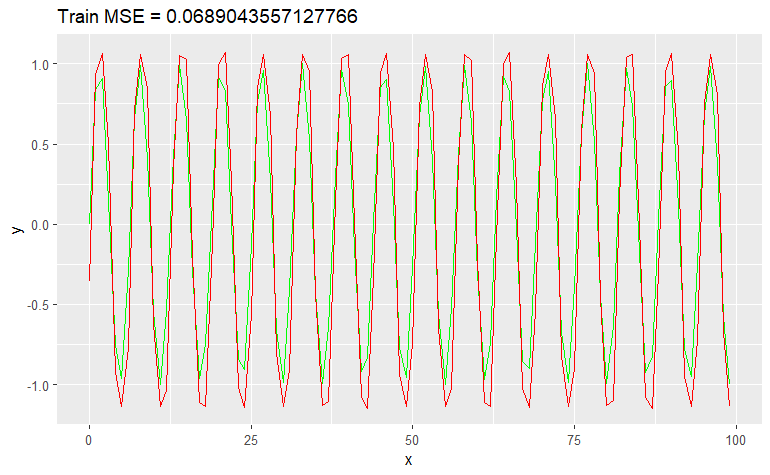

```r
ggplot(NULL, aes(x, y)) +
  geom_line(data = actual_df, color = "green") +
  geom_line(data = predicted_df, color = "red") +
  ggtitle(paste0("Train MSE = ", train_mse))
```

```r
test_X <- NULL
test_Y <- NULL
for (i in 200:299){
  test_X <- rbind(test_X, sin(i:(i+49)))
  test_Y <- rbind(test_Y, sin(i+50))
}
actual_test_df <- data.frame(x = 200:299, y = test_Y)

test_preds <- NULL
for (i in 1:dim(test_Y)[1]){
  x <- test_X[i,]
  y <- test_Y[i]
  prev_s <- rep(0, hidden_dim)
  for (t in 1:T){
    mulu <- U %*% x
    mulw <- W %*% prev_s
    add <- mulw + mulu
    s <- sigmoid(add)
    mulv <- V %*% s
    prev_s <- s
  test_preds <- rbind(test_preds, mulv)
  }
}
test_preds_df <- data.frame(x = 200:299, y = test_preds)

test_mse <- sum((actual_test_df[y] - test_preds_df[y])^2)/dim(actual_test_df[y])[1]
test_mse
```

```
[1] 0.04544418
```

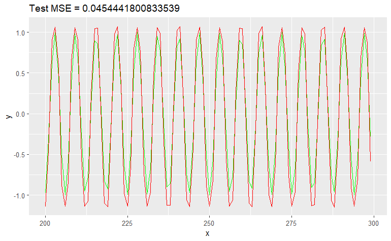

```r
ggplot(NULL, aes(x, y)) +
  geom_line(data = actual_test_df, color = "green") +
  geom_line(data = test_preds_df, color = "red") +
  ggtitle(paste0("Test MSE = ", test_mse))
```